# T5

### TCX3212 Predictive Analytics

### Tutorial/Lab 5

Learning Objectives

- Perform linear regression analysis using Python
- Interpret categorical variables in regression models
- Incorporate interaction terms into regression models

2026 Samantha Sow. National University of Singapore.

#### Setup

```python
# In JupyterLab, first navigate to the directory containing College.csv
# import os
# os.chdir('C:/')  # Replace with your actual path
```

```python
# Set-up Python libraries - you need to run this but you don't need to change it
import numpy as np
import matplotlib.pyplot as plt
import scipy.stats as stats
import pandas as pd
import seaborn as sns

sns.set_theme(style="white")
import statsmodels.api as sm
import statsmodels.formula.api as smf
```

```python
# load and view the data
df = pd.read_csv("Immigration.csv")
print(df)
print(df.head(5))
```

```
        id  better  bornuk  age     sex             educ             vote
0     1673       9       0   15  Female  Lower secondary  Any other party
1     1617       6       0   16  Female  Lower secondary  Any other party
2     1618       7       0   17  Female  Lower secondary  Any other party
3     1654       7       0   17  Female  Lower secondary  Any other party
4     1547       7       0   17  Female  Lower secondary  Any other party
...    ...     ...     ...  ...     ...              ...              ...
2114  1205       5       0   89    Male  Upper secondary           Labour
2115  1159       8       0   90    Male  Lower secondary           Labour
2116   710       4       0   90    Male  Lower secondary           Labour
2117  1120       7       1   90    Male  Lower secondary           Labour
2118  2131       0       0   90    Male         Tertiary           Labour

[2119 rows x 7 columns]
     id  better  bornuk  age     sex             educ             vote
0  1673       9       0   15  Female  Lower secondary  Any other party
1  1617       6       0   16  Female  Lower secondary  Any other party
2  1618       7       0   17  Female  Lower secondary  Any other party
3  1654       7       0   17  Female  Lower secondary  Any other party
4  1547       7       0   17  Female  Lower secondary  Any other party
```

#### Categorical Variables

a) Some of the common ideas about attitudes to immigration include that younger people tend to be more positive about immigration. Use the statsmodels.formula.api module to fit a simple linear regression using better as the response and age as the predictor. What does the coefficient estimate for the variable age suggest?

```python
import statsmodels.formula.api as smf

model = smf.ols("better ~ age", data=df).fit()

print(model.summary())
```

```
                            OLS Regression Results
==============================================================================
Dep. Variable:                 better   R-squared:                       0.078
Model:                            OLS   Adj. R-squared:                  0.077
Method:                 Least Squares   F-statistic:                     178.0
Date:                Sat, 07 Mar 2026   Prob (F-statistic):           4.67e-39
Time:                        23:04:22   Log-Likelihood:                -4818.3
No. Observations:                2119   AIC:                             9641.
Df Residuals:                    2117   BIC:                             9652.
Df Model:                           1
Covariance Type:            nonrobust
==============================================================================
                 coef    std err          t      P>|t|      [0.025      0.975]
------------------------------------------------------------------------------
Intercept      7.4102      0.153     48.501      0.000       7.111       7.710
age           -0.0367      0.003    -13.343      0.000      -0.042      -0.031
==============================================================================
Omnibus:                       55.831   Durbin-Watson:                   1.762
Prob(Omnibus):                  0.000   Jarque-Bera (JB):               56.391
Skew:                          -0.374   Prob(JB):                     5.69e-13
Kurtosis:                       2.717   Cond. No.                         166.
==============================================================================

Notes:
[1] Standard Errors assume that the covariance matrix of the errors is correctly specified.
```

The regression coefficient estimate for 'age' is -0.0367

b) We will now add a second independent variable to the regression model: sex ( a categorical variable with two levels: Male and Female). Update your regression model using the formula better ~ age + sex.

```python
model = smf.ols("better ~ age + C(sex, Treatment(reference='Female'))", data=df).fit()

print(model.summary())
```

```
                            OLS Regression Results
==============================================================================
Dep. Variable:                 better   R-squared:                       0.079
Model:                            OLS   Adj. R-squared:                  0.079
Method:                 Least Squares   F-statistic:                     91.36
Date:                Sat, 07 Mar 2026   Prob (F-statistic):           8.81e-39
Time:                        23:04:22   Log-Likelihood:                -4816.1
No. Observations:                2119   AIC:                             9638.
Df Residuals:                    2116   BIC:                             9655.
Df Model:                           2
Covariance Type:            nonrobust
=================================================================================================================
                                                    coef    std err          t      P>|t|      [0.025      0.975]
-----------------------------------------------------------------------------------------------------------------
Intercept                                         7.3235      0.158     46.299      0.000       7.013       7.634
C(sex, Treatment(reference='Female'))[T.Male]     0.2148      0.103      2.093      0.036       0.014       0.416
age                                              -0.0369      0.003    -13.419      0.000      -0.042      -0.032
==============================================================================
Omnibus:                       57.236   Durbin-Watson:                   1.766
Prob(Omnibus):                  0.000   Jarque-Bera (JB):               57.855
Skew:                          -0.379   Prob(JB):                     2.74e-13
Kurtosis:                       2.714   Cond. No.                         176.
==============================================================================

Notes:
[1] Standard Errors assume that the covariance matrix of the errors is correctly specified.
```

c) Which category (Male or Female) is serving as the reference (baseline) group? How can you tell? Based on the coefficient for sex[T.Male], do men or women have more positive attitudes toward immigration?

**Female** is serving as the reference (baseline) group.

We can tell because the model formula explicitly specifies `Treatment(reference='Female')`, and in the regression output the dummy variable shown is `C(sex, Treatment(reference='Female'))[T.Male]` — only Male appears as a coefficient, meaning Female is the omitted/baseline category.

The coefficient for `sex[T.Male]` is **+0.2148**, which is positive and statistically significant (p < 0.05). This means that, holding age constant, men score approximately 0.21 points *higher* on the `better` scale than women. Therefore, **men have more positive attitudes toward immigration** than women.

d) We will now add a third independent variable, education (educ) to the regression model. This is a categorical variable. What are its possible values? Based on the number of categories you found, how many dummy variables are needed?

```python
print("Possible values of educ:", df["educ"].unique())
print("Number of categories:", df["educ"].nunique())
print("Dummy variables needed:", df["educ"].nunique() - 1)

model2 = smf.ols(
    "better ~ age + C(sex, Treatment(reference='Female')) + educ", data=df
).fit()
print(model2.summary())
```

```
Possible values of educ: ['Lower secondary' 'Upper secondary' 'Tertiary']
Number of categories: 3
Dummy variables needed: 2
                            OLS Regression Results
==============================================================================
Dep. Variable:                 better   R-squared:                       0.144
Model:                            OLS   Adj. R-squared:                  0.142
Method:                 Least Squares   F-statistic:                     88.69
Date:                Sat, 07 Mar 2026   Prob (F-statistic):           9.37e-70
Time:                        23:04:22   Log-Likelihood:                -4739.5
No. Observations:                2119   AIC:                             9489.
Df Residuals:                    2114   BIC:                             9517.
Df Model:                           4
Covariance Type:            nonrobust
=================================================================================================================
                                                    coef    std err          t      P>|t|      [0.025      0.975]
-----------------------------------------------------------------------------------------------------------------
Intercept                                         6.3839      0.185     34.600      0.000       6.022       6.746
C(sex, Treatment(reference='Female'))[T.Male]     0.1833      0.099      1.850      0.064      -0.011       0.378
educ[T.Tertiary]                                  1.5831      0.132     12.031      0.000       1.325       1.841
educ[T.Upper secondary]                           0.4538      0.121      3.746      0.000       0.216       0.691
age                                              -0.0314      0.003    -11.625      0.000      -0.037      -0.026
==============================================================================
Omnibus:                       51.625   Durbin-Watson:                   1.803
Prob(Omnibus):                  0.000   Jarque-Bera (JB):               54.126
Skew:                          -0.380   Prob(JB):                     1.76e-12
Kurtosis:                       2.810   Cond. No.                         244.
==============================================================================

Notes:
[1] Standard Errors assume that the covariance matrix of the errors is correctly specified.
```

The possible values of `educ` are: **Lower secondary**, **Upper secondary**, and **Tertiary** — 3 categories in total.

Since we have 3 categories, we need **2 dummy variables** (number of categories − 1). The reference category (omitted group) is **Lower secondary** (chosen alphabetically by default), and the two dummies created are `educ[T.Tertiary]` and `educ[T.Upper secondary]`.

e) In research we often choose a specific “control” group as our comparison point. Now, we want to compare all education levels to “Upper secondary”. Update your regression model so that “Upper secondary” is the reference category for educ. You can do this by using slightly different syntax in your formula. Replace the variable educ with the code: C(educ, Treatment(reference="Upper secondary").

```python
model3 = smf.ols(
    'better ~ age + C(sex) + C(educ, Treatment(reference="Upper secondary"))',
    data=df,
).fit()
print(model3.summary())
```

```
                            OLS Regression Results
==============================================================================
Dep. Variable:                 better   R-squared:                       0.144
Model:                            OLS   Adj. R-squared:                  0.142
Method:                 Least Squares   F-statistic:                     88.69
Date:                Sat, 07 Mar 2026   Prob (F-statistic):           9.37e-70
Time:                        23:04:22   Log-Likelihood:                -4739.5
No. Observations:                2119   AIC:                             9489.
Df Residuals:                    2114   BIC:                             9517.
Df Model:                           4
Covariance Type:            nonrobust
======================================================================================================================================
                                                                         coef    std err          t      P>|t|      [0.025      0.975]
--------------------------------------------------------------------------------------------------------------------------------------
Intercept                                                              6.8377      0.163     41.848      0.000       6.517       7.158
C(sex)[T.Male]                                                         0.1833      0.099      1.850      0.064      -0.011       0.378
C(educ, Treatment(reference="Upper secondary"))[T.Lower secondary]    -0.4538      0.121     -3.746      0.000      -0.691      -0.216
C(educ, Treatment(reference="Upper secondary"))[T.Tertiary]            1.1293      0.118      9.560      0.000       0.898       1.361
age                                                                   -0.0314      0.003    -11.625      0.000      -0.037      -0.026
==============================================================================
Omnibus:                       51.625   Durbin-Watson:                   1.803
Prob(Omnibus):                  0.000   Jarque-Bera (JB):               54.126
Skew:                          -0.380   Prob(JB):                     1.76e-12
Kurtosis:                       2.810   Cond. No.                         202.
==============================================================================

Notes:
[1] Standard Errors assume that the covariance matrix of the errors is correctly specified.
```

f) How should you interpret the education coefficient estimates in the model? Are these differences statistically significant? Can you explain in words the relationship between education and immigration attitudes?

Compared to the baseline Upper secondary, the lower secondary group scores about 0.4538 lower points, and tertiary group scores about 1.1293. From this we can see that more educated groups perceive immigration to be better, as they give more points.

#### Interaction Terms

An interaction term in regression is used when the effect of one variable depends on the value of another variable. We want to see whether the effect of age on attitudes towards immigration (better) differs for people with different political preferences (vote).

g) To do this, fit a regression model that includes age, vote, and an interaction term between them (age:vote). (Hint: in Python, you can include an interaction between two variables A and B in your formula as A:B.) Note: You do not need to manually set a reference group for vote; the model will automatically select one category as the baseline (usually alphabetically).

```python
model_interaction = smf.ols("better ~ age + vote + age:vote", data=df).fit()
print(model_interaction.summary())
```

```
                            OLS Regression Results
==============================================================================
Dep. Variable:                 better   R-squared:                       0.103
Model:                            OLS   Adj. R-squared:                  0.101
Method:                 Least Squares   F-statistic:                     48.68
Date:                Sat, 07 Mar 2026   Prob (F-statistic):           8.28e-48
Time:                        23:04:22   Log-Likelihood:                -4788.4
No. Observations:                2119   AIC:                             9589.
Df Residuals:                    2113   BIC:                             9623.
Df Model:                           5
Covariance Type:            nonrobust
============================================================================================
                               coef    std err          t      P>|t|      [0.025      0.975]
--------------------------------------------------------------------------------------------
Intercept                    6.6209      0.285     23.229      0.000       6.062       7.180
vote[T.Conservative]         0.1307      0.376      0.347      0.728      -0.607       0.869
vote[T.Labour]               1.9364      0.388      4.994      0.000       1.176       2.697
age                         -0.0204      0.005     -3.824      0.000      -0.031      -0.010
age:vote[T.Conservative]    -0.0110      0.007     -1.614      0.107      -0.024       0.002
age:vote[T.Labour]          -0.0312      0.007     -4.312      0.000      -0.045      -0.017
==============================================================================
Omnibus:                       58.208   Durbin-Watson:                   1.813
Prob(Omnibus):                  0.000   Jarque-Bera (JB):               59.726
Skew:                          -0.389   Prob(JB):                     1.07e-13
Kurtosis:                       2.734   Cond. No.                         679.
==============================================================================

Notes:
[1] Standard Errors assume that the covariance matrix of the errors is correctly specified.
```

h) Write the regression equation separately for each vote group (baseline, Labour, Conservative), showing how intercepts and slopes differ because of the interaction term.

General regression equattion (not fitted)

Better = b0 + b1 onservative + b2labour + b3 age + b4 age*conservative + b5 age*labour

baseline: better = 6.6209 - 0.0204age (b0 + b3age) labour: better = 8.5573 - 0.0516age (b0 + b2labour + b3age + b5age*labour) conservative: better 6.7516 - 0.0314age (b0 + b1conservative + b3age + b4age*conservative)

i) In words, explain: How does the effect of age on better change across political groups?

The baseline group (Any other party) has a slope of **-0.0204**, meaning age has a relatively small negative effect on immigration attitudes for this group.

For **Labour** voters, the slope is **-0.0516** (= -0.0204 + (-0.0312)), which is the steepest negative slope. This means older Labour voters are considerably less positive about immigration compared to younger Labour voters — age has the strongest negative effect in this group.

For **Conservative** voters, the slope is **-0.0314** (= -0.0204 + (-0.0110)), which falls between the other two groups. Age has a moderate negative effect on immigration attitudes for Conservatives.

In summary, while age has a negative effect on immigration attitudes across **all** political groups, this effect is **strongest among Labour voters** and **weakest among those who voted for any other party**. This suggests that political affiliation moderates the relationship between age and attitudes toward immigration.

Group Points decrease per year Any other party −0.0204 Conservative −0.0314 Labour −0.0516

j) Visualize the interaction using sns.lmplot to show the linear relationship between better and age. Use hue='vote' to display separate lines for each voting category.

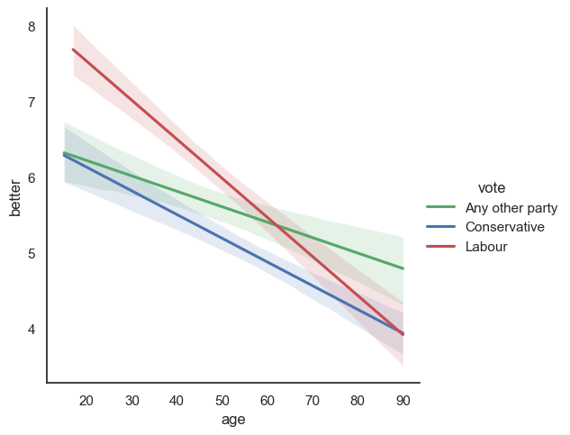

```python
sns.lmplot(
    data=df,
    x="age",
    y="better",
    hue="vote",
    scatter=False,
    palette={"Labour": "r", "Any other party": "g", "Conservative": "b"},
)
```